# Chapter 3

```r
require(data.table)
require(ggplot2)
theme_set(
    theme_bw(base_size = 14, base_family = "Lato") +
    theme(panel.grid = element_blank(), panel.border = element_blank())
)
```

Let’s continue with our NYC 311 service requests example.

```r
complaints <- fread("../data/311-service-requests.csv")
```

# 3.1 Selecting only noise complaints

I’d like to know which borough has the most noise complaints. First, we’ll take a look at the data to see what it looks like:

```r
complaints[1:6, 1:6] # look at the column `Complaint Type`
```

```
#>    Unique Key           Created Date            Closed Date Agency
#> 1:   26589651 10/31/2013 02:08:41 AM                          NYPD
#> 2:   26593698 10/31/2013 02:01:04 AM                          NYPD
#> 3:   26594139 10/31/2013 02:00:24 AM 10/31/2013 02:40:32 AM   NYPD
#> 4:   26595721 10/31/2013 01:56:23 AM 10/31/2013 02:21:48 AM   NYPD
#> 5:   26590930 10/31/2013 01:53:44 AM                         DOHMH
#> 6:   26592370 10/31/2013 01:46:52 AM                          NYPD
#>                                Agency Name          Complaint Type
#> 1:         New York City Police Department Noise - Street/Sidewalk
#> 2:         New York City Police Department         Illegal Parking
#> 3:         New York City Police Department      Noise - Commercial
#> 4:         New York City Police Department         Noise - Vehicle
#> 5: Department of Health and Mental Hygiene                  Rodent
#> 6:         New York City Police Department      Noise - Commercial
```

To get the noise complaints, we need to find the rows where the “Complaint Type” column is “Noise - Street/Sidewalk”. I’ll show you how to do that, and then explain what’s going on.

```r
noise_complaints <- complaints[`Complaint Type` == "Noise - Street/Sidewalk"]
noise_complaints[1:3, 1:10]
```

```
#>    Unique Key           Created Date            Closed Date Agency
#> 1:   26589651 10/31/2013 02:08:41 AM                          NYPD
#> 2:   26594086 10/31/2013 12:54:03 AM 10/31/2013 02:16:39 AM   NYPD
#> 3:   26591573 10/31/2013 12:35:18 AM 10/31/2013 02:41:35 AM   NYPD
#>                        Agency Name          Complaint Type
#> 1: New York City Police Department Noise - Street/Sidewalk
#> 2: New York City Police Department Noise - Street/Sidewalk
#> 3: New York City Police Department Noise - Street/Sidewalk
#>          Descriptor   Location Type Incident Zip    Incident Address
#> 1:     Loud Talking Street/Sidewalk        11432    90-03 169 STREET
#> 2: Loud Music/Party Street/Sidewalk        10310 173 CAMPBELL AVENUE
#> 3:     Loud Talking Street/Sidewalk        10312   24 PRINCETON LANE
```

If you look at `noise_complaints`, you’ll see that this worked, and it only contains complaints with the right complaint type. But how does this work? Let’s deconstruct it into two pieces.

```r
complaints[, `Complaint Type` == "Noise - Street/Sidewalk"][1:10]
```

```
#>  [1]  TRUE FALSE FALSE FALSE FALSE FALSE FALSE FALSE FALSE FALSE
```

This is a big array of `TRUE` and `FALSE` , one for each row in our dataframe. When we index our dataframe with this array, we get just the rows where our boolean array evaluated to True. It’s important to note that for row filtering by a boolean array the length of our dataframe’s index must be the same length as the boolean array used for filtering.

You can also combine more than one condition with the & operator like this:

```r
is_noise <- complaints[, `Complaint Type` == "Noise - Street/Sidewalk"]
in_brooklyn <- complaints[, `Borough` == "BROOKLYN"]
complaints[is_noise & in_brooklyn][1:6, 1:6]
```

```
#>    Unique Key           Created Date            Closed Date Agency
#> 1:   26595564 10/31/2013 12:30:36 AM                          NYPD
#> 2:   26595553 10/31/2013 12:05:10 AM 10/31/2013 02:43:43 AM   NYPD
#> 3:   26594653 10/30/2013 11:26:32 PM 10/31/2013 12:18:54 AM   NYPD
#> 4:   26591992 10/30/2013 10:02:58 PM 10/30/2013 10:23:20 PM   NYPD
#> 5:   26594167 10/30/2013 08:38:25 PM 10/30/2013 10:26:28 PM   NYPD
#> 6:   26590110 10/30/2013 08:32:13 PM 10/30/2013 11:58:00 PM   NYPD
#>                        Agency Name          Complaint Type
#> 1: New York City Police Department Noise - Street/Sidewalk
#> 2: New York City Police Department Noise - Street/Sidewalk
#> 3: New York City Police Department Noise - Street/Sidewalk
#> 4: New York City Police Department Noise - Street/Sidewalk
#> 5: New York City Police Department Noise - Street/Sidewalk
#> 6: New York City Police Department Noise - Street/Sidewalk
```

```r
## or if we wanted a few columns
complaints[is_noise & in_brooklyn][1:6, c('Complaint Type', 'Borough', 'Created Date', 'Descriptor')]
```

```
#>             Complaint Type  Borough           Created Date
#> 1: Noise - Street/Sidewalk BROOKLYN 10/31/2013 12:30:36 AM
#> 2: Noise - Street/Sidewalk BROOKLYN 10/31/2013 12:05:10 AM
#> 3: Noise - Street/Sidewalk BROOKLYN 10/30/2013 11:26:32 PM
#> 4: Noise - Street/Sidewalk BROOKLYN 10/30/2013 10:02:58 PM
#> 5: Noise - Street/Sidewalk BROOKLYN 10/30/2013 08:38:25 PM
#> 6: Noise - Street/Sidewalk BROOKLYN 10/30/2013 08:32:13 PM
#>          Descriptor
#> 1: Loud Music/Party
#> 2:     Loud Talking
#> 3: Loud Music/Party
#> 4:     Loud Talking
#> 5: Loud Music/Party
#> 6:     Loud Talking
```

# 3.2 A digression about numpy arrays

# 3.3 So, which borough has the most noise complaints?

```r
noise_complaints <- complaints[`Complaint Type` == "Noise - Street/Sidewalk"]
count_noise_complaints <- noise_complaints[, .(n_noise = .N), by = .(Borough)][order(n_noise, decreasing = TRUE)]

count_noise_complaints <- merge(count_noise_complaints,
                                complaints[, .(n_complaint = .N), by = .(Borough)],
                                by = "Borough")

count_noise_complaints[, p_noise := n_noise / n_complaint]
print(count_noise_complaints)
```

```
#>          Borough n_noise n_complaint      p_noise
#> 1:         BRONX     292       19686 0.0148328762
#> 2:      BROOKLYN     456       32890 0.0138643965
#> 3:     MANHATTAN     917       24288 0.0377552701
#> 4:        QUEENS     226       22281 0.0101431713
#> 5: STATEN ISLAND      36        4817 0.0074735312
#> 6:   Unspecified       1        7107 0.0001407063
```

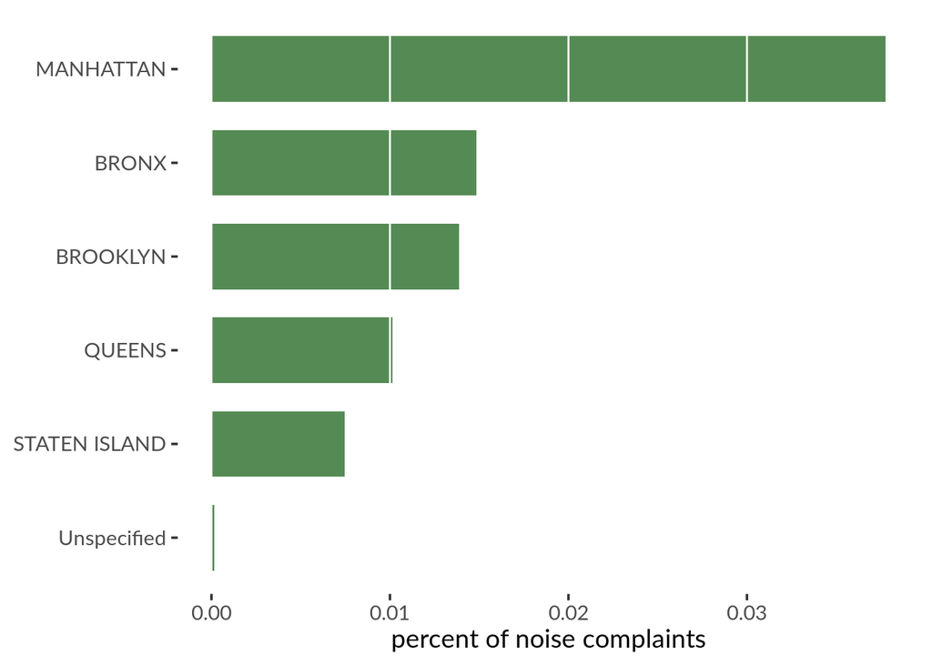

```r
ggplot(count_noise_complaints, aes(reorder(Borough, p_noise), p_noise)) +
    geom_col(fill = "palegreen4", width = 0.7) +
    geom_hline(yintercept = seq(0, 0.03, 0.01), color = "white") +
    labs(x = NULL, y = "percent of noise complaints") +
    coord_flip()
```

So Manhattan really does complain more about noise than the other boroughs! Neat.